# Assignment 4 — Customer Churn Prediction for Loblaws Digital

Prepared by Scrum Team 3 — CropYieldPrediction

1. **Hasyashri Bhatt**-
2. **Baban**-
3. **Fenil** -
4. **Shrinu** -

#### **1. Introduction**

Loblaws Digital wants to predict which customers are most likely to leave the platform (churn). Customer churn is expensive — each lost customer means lost revenue, higher marketing costs, and lower loyalty.

**Our job is to:**

- build a model that predicts churn
- identify important customer behaviors
- help the business make decisions to prevent churn

**This notebook walks through everything:**

- Data cleaning
- Exploratory analysis
- Feature engineering
- Modeling
- Tuning
- Deployment planning
- Performance management

##### **2. Assignment Objectives**

**Business Objectives**

- Predict customers who are likely to leave Loblaws.
- Help the company improve customer retention.
- Understand which factors influence churn.
- Provide clear, actionable insights to Product Managers.

**Technical Objectives**

- Perform detailed EDA
- Build ML models (Logistic Regression, Random Forest, XGBoost)
- Tune hyperparameters
- Select the best model
- Save the final model for deployment

#### **3. Problem Definition**

**Goal:**

Build a Machine Learning model that predicts whether a customer will churn (Yes/No).

**This is a binary classification problem:**

| Label | Meaning |
| --- | --- |
| **1** | Customer churns (leaves) |
| **0** | Customer stays |

#### **4. Stakeholders**

| **Stakeholder** | **What They Care About** |
| --- | --- |
| **Product Managers** | Which customers need retention offers |
| **Marketing Team** | Who to target with discounts |
| **Customer Service** | Who may need intervention |
| **Leadership** | KPIs, churn rate, ROI |
| **Data Science Team** | Model accuracy, fairness, reliability |

# PART 1

#### **5. Integration Plan (Part 1 of Assignment)**

**5.1 Business Context & Stakeholders**

Loblaws operates a large e-commerce ecosystem. Customer churn costs the business money. This churn prediction model will integrate into:

- CRM systems
- Customer notification tools
- Marketing dashboards
- Loyalty program systems

**Target Users:**

- Marketing analysts
- Customer retention managers
- Automated retention pipelines

**5.2 Integration Architecture** Below is a simple diagram showing how the churn model fits into the ecosystem:

```
             ┌─────────────────────────────┐
             │     Customer Databases      │
             └──────────────┬──────────────┘
                            │
                            ▼
                 ┌────────────────────┐
                 │  Data Pipeline     │
                 │ (ETL + Cleaning)   │
                 └─────────┬──────────┘
                           │
                           ▼
              ┌───────────────────────────┐
              │  Churn Prediction Model   │
              │ (XGBoost + Scaler)        │
              └───────────┬───────────────┘
                          │
                          ▼
          ┌────────────────────────────────────────┐
          │ Retention Actions (Email, SMS, Coupons)│
          └────────────────────────────────────────┘
```

#### **Detailed Flowchart for the integration:**

[figure not shown]

**5.3 Data Flow & Security Plan**

**Data Sources**

- Customer profile data
- Order activity
- Complaints
- Cashback & coupons
- Device usage
- Tenure
- CRM, transaction DB

**Data Security Measures**

- Encryption
- Secure cloud storage (AWS S3 / GCP Storage)
- Access control
- Model endpoints protected using API Gateway + Auth
- privacy laws,GDPR compliance

**Processing Steps**

Pipeline: ETL → Feature Engineering → Prediction → Dashboard

**5.4 Deployment & Scaling Plan**

- Cloud deployment (AWS/GCP/Azure)
- Batch or real-time scoring

**Scaling Strategy**

- Containerization using Docker
- CI/CD pipeline for updates

**5.5 Risk Assessment & Mitigation**

| **Risk** | **Impact** | **Mitigation** |
| --- | --- | --- |
| Data drift | Model becomes inaccurate | Add monitoring, automatic retraining |
| Imbalanced classes | Poor detection of churners | Use class weights, SMOTE |
| Privacy concerns | Legal issues | Mask all PII, encrypt data |
| Wrong retention actions | Customer dissatisfaction | Human review of high-risk cases |
| Integration failure | Broken workflows | API testing + fallback rules |

# PART 3

#### **6. KPIs (Part 3 of Assignment: Performance Management)**

**To evaluate the model, we use:**

**Intrinsic KPIs (model performance)**

- Accuracy
- Precision
- Recall (VERY important in churn prediction)
- F1 Score
- ROC-AUC
- Latency per prediction (< 50 ms)
- Feature importance stability

**Extrinsic KPIs (business performance)**

- Reduction in churn rate
- Increase in retention campaign ROI
- Cost saved per retained customer
- Customer engagement uplift

#### **7. Validation Approach**

**Intrinsic Validation**

- Train/test split
- Stratified cross validation
- Hyperparameter tuning
- Calibration plots
- Threshold optimization

**Extrinsic Validation**

- A/B testing retention strategies
- Compare churn before vs after model use
- Measure uplift from coupons sent to high-risk customers

# NOTEBOOK

#### 1. Libraries

Import all necessary libraries for data analysis, modeling, and visualization.

- **pandas** → helps us work with tables
- **numpy** → helps with numbers
- **matplotlib / seaborn** → used to draw graphs
- **sklearn** → used for machine learning
- **warnings** → hides extra warning messages

```python
import pandas as pd
import numpy as np
import matplotlib.pyplot as plt
import seaborn as sns
import shap
import warnings
import joblib

warnings.filterwarnings("ignore")
sns.set(style="whitegrid")

from sklearn.model_selection import train_test_split, GridSearchCV, StratifiedKFold
from sklearn.preprocessing import StandardScaler
from sklearn.impute import SimpleImputer
from sklearn.linear_model import LogisticRegression
from sklearn.ensemble import RandomForestClassifier
from xgboost import XGBClassifier
from sklearn.metrics import (
    accuracy_score, precision_score, recall_score, f1_score,
    roc_auc_score, confusion_matrix, classification_report, roc_curve
)

print("Libraries imported")
```

```
Libraries imported
```

[output not shown]

#### 2. Load the Dataset

We load the `loblaws.xlsx` file.  
The sheet inside the file is named **"E Comm"**, which contains customer information.

After loading, we check:

- The number of rows and columns
- A preview of the first 5 rows
- The data types of each column

This helps us understand the shape and structure of the data.

```python
df = pd.read_excel("loblaws.xlsx", sheet_name="E Comm")
print(f"Dataset shape: {df.shape}")
display(df.head())
```

```
Dataset shape: (5630, 20)
```

|  | CustomerID | Churn | Tenure | PreferredLoginDevice | CityTier | WarehouseToHome | PreferredPaymentMode | Gender | HourSpendOnApp | NumberOfDeviceRegistered | PreferedOrderCat | SatisfactionScore | MaritalStatus | NumberOfAddress | Complain | OrderAmountHikeFromlastYear | CouponUsed | OrderCount | DaySinceLastOrder | CashbackAmount |
| --- | --- | --- | --- | --- | --- | --- | --- | --- | --- | --- | --- | --- | --- | --- | --- | --- | --- | --- | --- | --- |
| 0 | 50001 | 1 | 4.0 | Mobile Phone | 3 | 6.0 | Debit Card | Female | 3.0 | 3 | Laptop & Accessory | 2 | Single | 9 | 1 | 11.0 | 1.0 | 1.0 | 5.0 | 159.93 |
| 1 | 50002 | 1 | NaN | Phone | 1 | 8.0 | UPI | Male | 3.0 | 4 | Mobile | 3 | Single | 7 | 1 | 15.0 | 0.0 | 1.0 | 0.0 | 120.90 |
| 2 | 50003 | 1 | NaN | Phone | 1 | 30.0 | Debit Card | Male | 2.0 | 4 | Mobile | 3 | Single | 6 | 1 | 14.0 | 0.0 | 1.0 | 3.0 | 120.28 |
| 3 | 50004 | 1 | 0.0 | Phone | 3 | 15.0 | Debit Card | Male | 2.0 | 4 | Laptop & Accessory | 5 | Single | 8 | 0 | 23.0 | 0.0 | 1.0 | 3.0 | 134.07 |
| 4 | 50005 | 1 | 0.0 | Phone | 1 | 12.0 | CC | Male | NaN | 3 | Mobile | 5 | Single | 3 | 0 | 11.0 | 1.0 | 1.0 | 3.0 | 129.60 |

```python
# Show data types
df.dtypes
```

```
CustomerID                       int64
Churn                            int64
Tenure                         float64
PreferredLoginDevice            object
CityTier                         int64
WarehouseToHome                float64
PreferredPaymentMode            object
Gender                          object
HourSpendOnApp                 float64
NumberOfDeviceRegistered         int64
PreferedOrderCat                object
SatisfactionScore                int64
MaritalStatus                   object
NumberOfAddress                  int64
Complain                         int64
OrderAmountHikeFromlastYear    float64
CouponUsed                     float64
OrderCount                     float64
DaySinceLastOrder              float64
CashbackAmount                 float64
dtype: object
```

I loaded the customer data.The table has 5630 rows (customers) and 20 columns (customer details). I checked how the data looks and what type of information is stored inside.

#### 3. Checking Data Quality

Before building a machine learning model,

we must check if the data has:

- Missing values (empty cells)
- Strange numbers (outliers)
- Mixed or messy categories for e.g., “Phone” vs “Mobile Phone”

we will create:

- A **missing value chart**
- A summary of numeric features
- A list of unique values for each category

```
Missing Value Summary:
```

|  | Missing Values | Missing (%) |
| --- | --- | --- |
| DaySinceLastOrder | 307 | 5.45 |
| OrderAmountHikeFromlastYear | 265 | 4.71 |
| Tenure | 264 | 4.69 |
| OrderCount | 258 | 4.58 |
| CouponUsed | 256 | 4.55 |
| HourSpendOnApp | 255 | 4.53 |
| WarehouseToHome | 251 | 4.46 |
| CustomerID | 0 | 0.00 |
| MaritalStatus | 0 | 0.00 |
| Complain | 0 | 0.00 |
| NumberOfAddress | 0 | 0.00 |
| PreferedOrderCat | 0 | 0.00 |
| SatisfactionScore | 0 | 0.00 |
| Churn | 0 | 0.00 |
| NumberOfDeviceRegistered | 0 | 0.00 |
| Gender | 0 | 0.00 |
| PreferredPaymentMode | 0 | 0.00 |
| CityTier | 0 | 0.00 |
| PreferredLoginDevice | 0 | 0.00 |
| CashbackAmount | 0 | 0.00 |

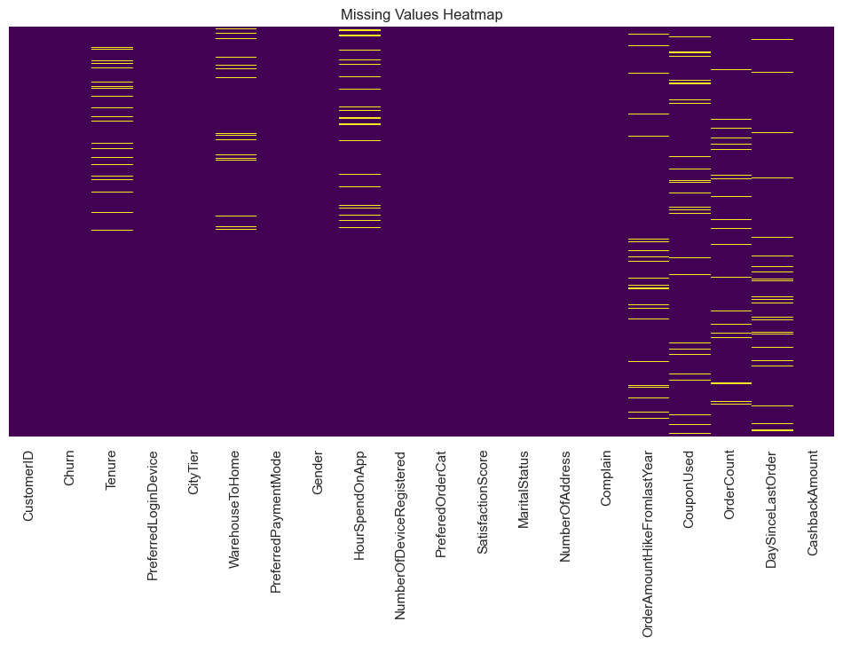

```python
# ===============================
# Missing Values Check
# ===============================

# Count missing values
missing_counts = df.isnull().sum()

# Percentage of missing values
missing_percent = (missing_counts / len(df)) * 100

# Combine into a table
missing_table = pd.DataFrame({
    "Missing Values": missing_counts,
    "Missing (%)": missing_percent.round(2)
}).sort_values(by="Missing (%)", ascending=False)

print("Missing Value Summary:")
display(missing_table)

# Visualize missing values
plt.figure(figsize=(12,6))
sns.heatmap(df.isnull(), cbar=False, yticklabels=False, cmap="viridis")
plt.title("Missing Values Heatmap")
plt.show()
```

## Insights on Missing Values

The analysis reveals that a few columns, such as `DaySinceLastOrder`, `Tenure`, and `OrderCount`, have around 4–5% missing values, indicating that some customer information is incomplete. Most other columns, including `CustomerID`, `Gender`, and `Churn`, are complete.

Next, we define an imputation strategy:

- Numeric columns → median
- Categorical columns → most frequent value

**Business Insight:** Ensuring no customer segment is excluded improves model reliability and fairness.

# 4. Outliers & Category Checks

After handling missing values, it is important to explore numeric and categorical columns for anomalies. Numeric features will be summarized with descriptive statistics and visualized with boxplots to detect outliers. Categorical features will be inspected for inconsistent labels or unexpected categories.

```python
numeric_cols = df.select_dtypes(include=['int64','float64']).columns.tolist()
categorical_cols = df.select_dtypes(include=['object']).columns.tolist()

display(df[numeric_cols].describe().T)



for col in categorical_cols:
    print(f"{col}: {df[col].unique()}")
```

|  | count | mean | std | min | 25% | 50% | 75% | max |
| --- | --- | --- | --- | --- | --- | --- | --- | --- |
| CustomerID | 5630.0 | 52815.500000 | 1625.385339 | 50001.0 | 51408.25 | 52815.50 | 54222.7500 | 55630.00 |
| Churn | 5630.0 | 0.168384 | 0.374240 | 0.0 | 0.00 | 0.00 | 0.0000 | 1.00 |
| Tenure | 5366.0 | 10.189899 | 8.557241 | 0.0 | 2.00 | 9.00 | 16.0000 | 61.00 |
| CityTier | 5630.0 | 1.654707 | 0.915389 | 1.0 | 1.00 | 1.00 | 3.0000 | 3.00 |
| WarehouseToHome | 5379.0 | 15.639896 | 8.531475 | 5.0 | 9.00 | 14.00 | 20.0000 | 127.00 |
| HourSpendOnApp | 5375.0 | 2.931535 | 0.721926 | 0.0 | 2.00 | 3.00 | 3.0000 | 5.00 |
| NumberOfDeviceRegistered | 5630.0 | 3.688988 | 1.023999 | 1.0 | 3.00 | 4.00 | 4.0000 | 6.00 |
| SatisfactionScore | 5630.0 | 3.066785 | 1.380194 | 1.0 | 2.00 | 3.00 | 4.0000 | 5.00 |
| NumberOfAddress | 5630.0 | 4.214032 | 2.583586 | 1.0 | 2.00 | 3.00 | 6.0000 | 22.00 |
| Complain | 5630.0 | 0.284902 | 0.451408 | 0.0 | 0.00 | 0.00 | 1.0000 | 1.00 |
| OrderAmountHikeFromlastYear | 5365.0 | 15.707922 | 3.675485 | 11.0 | 13.00 | 15.00 | 18.0000 | 26.00 |
| CouponUsed | 5374.0 | 1.751023 | 1.894621 | 0.0 | 1.00 | 1.00 | 2.0000 | 16.00 |
| OrderCount | 5372.0 | 3.008004 | 2.939680 | 1.0 | 1.00 | 2.00 | 3.0000 | 16.00 |
| DaySinceLastOrder | 5323.0 | 4.543491 | 3.654433 | 0.0 | 2.00 | 3.00 | 7.0000 | 46.00 |
| CashbackAmount | 5630.0 | 177.223030 | 49.207036 | 0.0 | 145.77 | 163.28 | 196.3925 | 324.99 |

```
PreferredLoginDevice: ['Mobile Phone' 'Phone' 'Computer']
PreferredPaymentMode: ['Debit Card' 'UPI' 'CC' 'Cash on Delivery' 'E wallet' 'COD' 'Credit Card']
Gender: ['Female' 'Male']
PreferedOrderCat: ['Laptop & Accessory' 'Mobile' 'Mobile Phone' 'Others' 'Fashion' 'Grocery']
MaritalStatus: ['Single' 'Divorced' 'Married']
```

**Insight:** Identifying outliers ensures accurate modeling of high-value or at-risk customers. Some categories had different spellings e.g., "Phone", "Mobile", "Mobile Phone",COD, cash on Delivery'. Some numbers looked too big or too small and might be outliers.

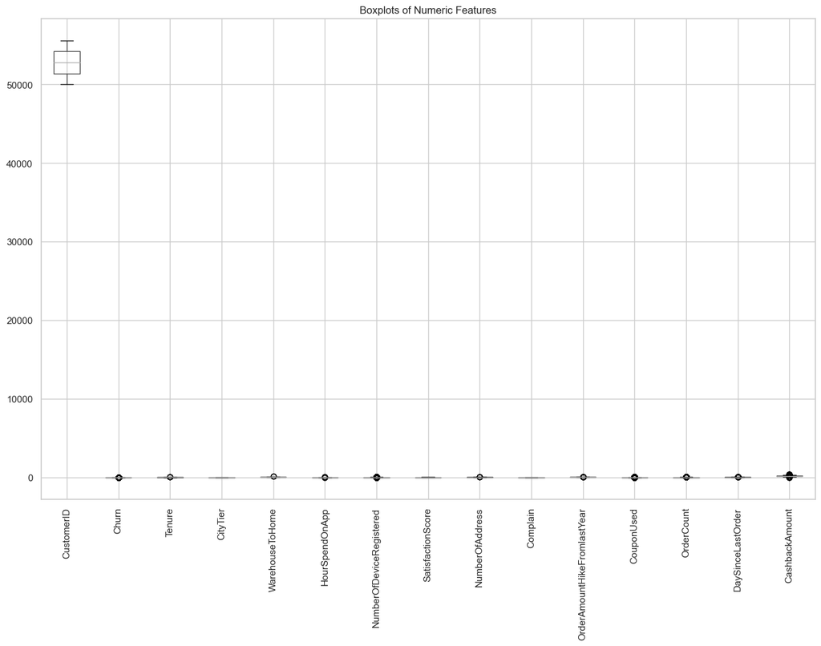

```python
plt.figure(figsize=(16,10))
df[numeric_cols].boxplot(rot=90)
plt.title("Boxplots of Numeric Features")
plt.show()
```

**Business Insight:** Outliers can distort predictions; identifying them ensures high-value customers are modeled accurately.

## Insights on Outliers & Categories

- Boxplots reveal that features like `WarehouseToHome` and `OrderCount` contain outliers.
- Categorical inspection shows inconsistent labels, e.g., 'COD' vs 'Cash on Delivery', 'CC' vs 'Credit Card', 'Mobile' vs 'Mobile Phone'.

Standardizing these categories will prevent issues during encoding.

Next we will clean the data so our model training will be good.

# 5. Data Cleaning & Imputation

We fix messy or missing data so our model can learn correctly.

### Steps we perform:

1. **Standardize category names**
   - Example: "COD" → "Cash on Delivery"
   - Example: "Phone" → "Mobile Phone"
2. **Fill missing values**
   - Numbers → replaced with the **median**
   - Categories → replaced with the **most common value**
3. **Check that no missing values remain**

```python
clean_df = df.copy()

# Standardize categories
clean_df['PreferredPaymentMode'] = clean_df['PreferredPaymentMode'].replace({'COD':'Cash on Delivery','CC':'Credit Card'})
clean_df['PreferedOrderCat'] = clean_df['PreferedOrderCat'].replace({'Mobile':'Mobile Phone'})
clean_df['PreferredLoginDevice'] = clean_df['PreferredLoginDevice'].replace({'Phone':'Mobile Phone'})

# Imputation
numeric_imputer = SimpleImputer(strategy='median')
categorical_imputer = SimpleImputer(strategy='most_frequent')
clean_df[numeric_cols] = numeric_imputer.fit_transform(clean_df[numeric_cols])
clean_df[categorical_cols] = categorical_imputer.fit_transform(clean_df[categorical_cols])

print("Missing Values After Imputation:")
print(clean_df.isnull().sum())
display(clean_df.head())
```

```
Missing Values After Imputation:
CustomerID                     0
Churn                          0
Tenure                         0
PreferredLoginDevice           0
CityTier                       0
WarehouseToHome                0
PreferredPaymentMode           0
Gender                         0
HourSpendOnApp                 0
NumberOfDeviceRegistered       0
PreferedOrderCat               0
SatisfactionScore              0
MaritalStatus                  0
NumberOfAddress                0
Complain                       0
OrderAmountHikeFromlastYear    0
CouponUsed                     0
OrderCount                     0
DaySinceLastOrder              0
CashbackAmount                 0
dtype: int64
```

|  | CustomerID | Churn | Tenure | PreferredLoginDevice | CityTier | WarehouseToHome | PreferredPaymentMode | Gender | HourSpendOnApp | NumberOfDeviceRegistered | PreferedOrderCat | SatisfactionScore | MaritalStatus | NumberOfAddress | Complain | OrderAmountHikeFromlastYear | CouponUsed | OrderCount | DaySinceLastOrder | CashbackAmount |
| --- | --- | --- | --- | --- | --- | --- | --- | --- | --- | --- | --- | --- | --- | --- | --- | --- | --- | --- | --- | --- |
| 0 | 50001.0 | 1.0 | 4.0 | Mobile Phone | 3.0 | 6.0 | Debit Card | Female | 3.0 | 3.0 | Laptop & Accessory | 2.0 | Single | 9.0 | 1.0 | 11.0 | 1.0 | 1.0 | 5.0 | 159.93 |
| 1 | 50002.0 | 1.0 | 9.0 | Mobile Phone | 1.0 | 8.0 | UPI | Male | 3.0 | 4.0 | Mobile Phone | 3.0 | Single | 7.0 | 1.0 | 15.0 | 0.0 | 1.0 | 0.0 | 120.90 |
| 2 | 50003.0 | 1.0 | 9.0 | Mobile Phone | 1.0 | 30.0 | Debit Card | Male | 2.0 | 4.0 | Mobile Phone | 3.0 | Single | 6.0 | 1.0 | 14.0 | 0.0 | 1.0 | 3.0 | 120.28 |
| 3 | 50004.0 | 1.0 | 0.0 | Mobile Phone | 3.0 | 15.0 | Debit Card | Male | 2.0 | 4.0 | Laptop & Accessory | 5.0 | Single | 8.0 | 0.0 | 23.0 | 0.0 | 1.0 | 3.0 | 134.07 |
| 4 | 50005.0 | 1.0 | 0.0 | Mobile Phone | 1.0 | 12.0 | Credit Card | Male | 3.0 | 3.0 | Mobile Phone | 5.0 | Single | 3.0 | 0.0 | 11.0 | 1.0 | 1.0 | 3.0 | 129.60 |

**Business Insight:** Standardization and imputation prevent bias and ensure consistent predictions.

## Summary & Next Steps

After preprocessing, the dataset is fully clean, with missing values imputed and categorical inconsistencies resolved. Next steps:

1. Perform Exploratory Data Analysis (EDA)
2. Feature engineering
3. Machine learning modeling
4. Model evaluation & interpretation

# 6. Exploratory Data Analysis (EDA)

EDA helps us understand patterns in the data.

We check:

### How many customers churned

### How churn relates to tenure

### The correlation between features

### Basic patterns across the dataset

This step helps us understand what affects churn.

## 6.1 Churn Distribution

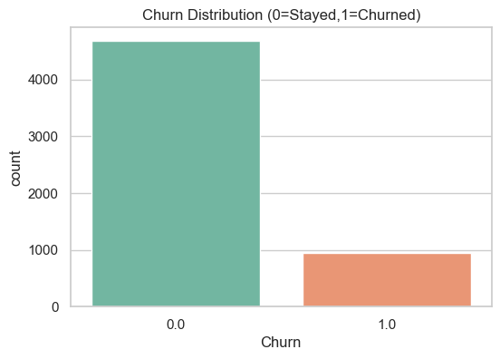

```
Churn %:
 Churn
0.0    83.16
1.0    16.84
Name: proportion, dtype: float64
Insight: Churn is imbalanced → class weighting or threshold tuning required.
```

```python
plt.figure(figsize=(6,4))
sns.countplot(x='Churn', data=clean_df, palette='Set2')
plt.title('Churn Distribution (0=Stayed,1=Churned)')
plt.show()

churn_percent = (clean_df['Churn'].value_counts(normalize=True)*100).round(2)
print("Churn %:\n", churn_percent)

print("Insight: Churn is imbalanced → class weighting or threshold tuning required.")
```

**Insight:** The churn class is imbalanced. Minority class weighting or threshold adjustments are required for accurate retention targeting.

## 6.2 Correlation Heatmap

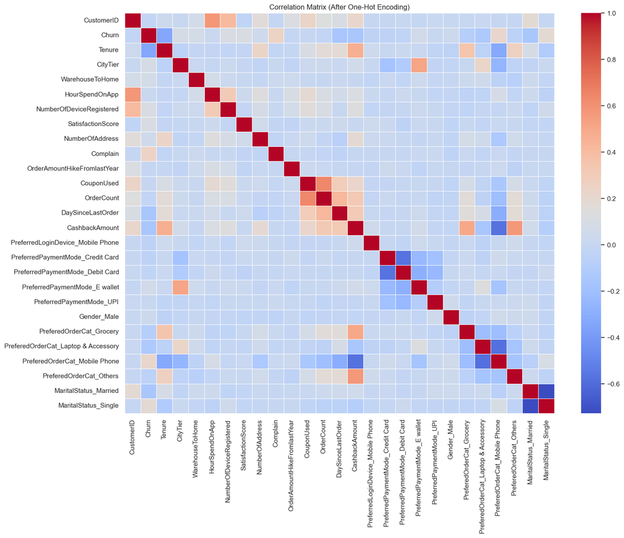

```python
# Identify categorical columns
categorical_cols_clean = clean_df.select_dtypes(include=['object']).columns.tolist()

# Apply one-hot encoding to categorical columns
df_encoded = pd.get_dummies(clean_df, columns=categorical_cols_clean, drop_first=True)

plt.figure(figsize=(16, 12))
sns.heatmap(df_encoded.corr(), annot=False, fmt=".2f", cmap='coolwarm', linewidths=.5)
plt.title("Correlation Matrix (After One-Hot Encoding)")
plt.show()
```

## 6.3 Feature vs Churn Plots (Business Insight)

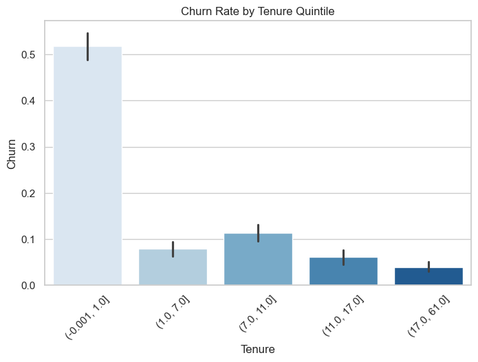

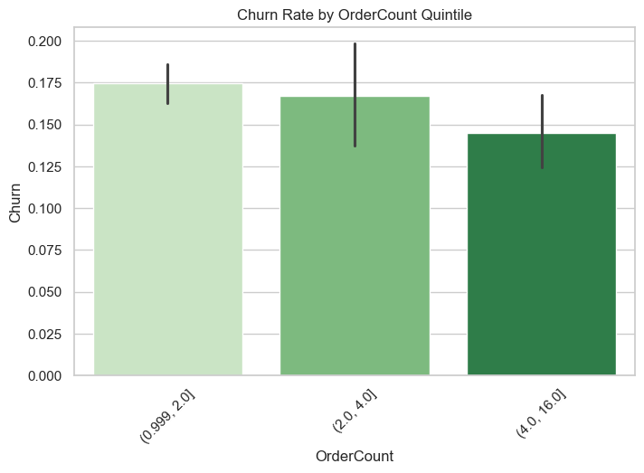

```python
plt.figure(figsize=(8,5))
sns.barplot(x=pd.qcut(clean_df['Tenure'], 5), y='Churn', data=clean_df, palette='Blues')
plt.title("Churn Rate by Tenure Quintile")
plt.xticks(rotation=45)
plt.show()

plt.figure(figsize=(8,5))
sns.barplot(x=pd.qcut(clean_df['OrderCount'],5, duplicates='drop'), y='Churn', data=clean_df, palette='Greens')
plt.title("Churn Rate by OrderCount Quintile")
plt.xticks(rotation=45)
plt.show()
```

#### **Insights:**

- Only 17% of customers churned (data is imbalanced).
- Customers with lower tenure churn more.
- Some features are correlated, which our model must handle.
- This helps us create better, smarter features.

# 7. Feature Engineering

Feature engineering means **creating new useful data columns**  
that help the model learn better patterns.

We add:

- **RecencyBucket** → how recently the customer ordered
- **LoyaltyScore** → bigger score = more loyal
- **CouponUsageRatio** → how often they use coupons
- **ComplaintFrequency** → how often they complain
- **CashbackPerOrder** → average cashback per order
- **HighRiskCategory** → customers who buy “Mobile Phone” often

Then we one-hot encode (convert text to numbers) the categorical features to Numeric.

```python
df_fe = clean_df.copy()

df_fe['RecencyBucket'] = pd.cut(df_fe['DaySinceLastOrder'], bins=[-1,2,5,10,50],
                                labels=['Very Recent','Recent','Moderate','High'])
df_fe['LoyaltyScore'] = df_fe['Tenure']*0.5 + df_fe['OrderCount']*1.5
df_fe['CouponUsageRatio'] = df_fe['CouponUsed'] / (df_fe['OrderCount']+1)
df_fe['ComplaintFrequency'] = df_fe['Complain'] / (df_fe['NumberOfAddress']+1)
df_fe['CashbackPerOrder'] = df_fe['CashbackAmount'] / (df_fe['OrderCount']+1)
df_fe['HighRiskCategory'] = df_fe['PreferedOrderCat'].apply(lambda x: 1 if x=='Mobile Phone' else 0)

categorical_cols_fe = ['PreferredLoginDevice','PreferredPaymentMode','Gender','PreferedOrderCat',
                       'MaritalStatus','RecencyBucket','CityTier']
df_fe = pd.get_dummies(df_fe, columns=categorical_cols_fe, drop_first=True)

print("Feature engineering complete. Shape:", df_fe.shape)
display(df_fe.head())
```

```
Feature engineering complete. Shape: (5630, 36)
```

|  | CustomerID | Churn | Tenure | WarehouseToHome | HourSpendOnApp | NumberOfDeviceRegistered | SatisfactionScore | NumberOfAddress | Complain | OrderAmountHikeFromlastYear | ... | PreferedOrderCat_Laptop & Accessory | PreferedOrderCat_Mobile Phone | PreferedOrderCat_Others | MaritalStatus_Married | MaritalStatus_Single | RecencyBucket_Recent | RecencyBucket_Moderate | RecencyBucket_High | CityTier_2.0 | CityTier_3.0 |
| --- | --- | --- | --- | --- | --- | --- | --- | --- | --- | --- | --- | --- | --- | --- | --- | --- | --- | --- | --- | --- | --- |
| 0 | 50001.0 | 1.0 | 4.0 | 6.0 | 3.0 | 3.0 | 2.0 | 9.0 | 1.0 | 11.0 | ... | True | False | False | False | True | True | False | False | False | True |
| 1 | 50002.0 | 1.0 | 9.0 | 8.0 | 3.0 | 4.0 | 3.0 | 7.0 | 1.0 | 15.0 | ... | False | True | False | False | True | False | False | False | False | False |
| 2 | 50003.0 | 1.0 | 9.0 | 30.0 | 2.0 | 4.0 | 3.0 | 6.0 | 1.0 | 14.0 | ... | False | True | False | False | True | True | False | False | False | False |
| 3 | 50004.0 | 1.0 | 0.0 | 15.0 | 2.0 | 4.0 | 5.0 | 8.0 | 0.0 | 23.0 | ... | True | False | False | False | True | True | False | False | False | True |
| 4 | 50005.0 | 1.0 | 0.0 | 12.0 | 3.0 | 3.0 | 5.0 | 3.0 | 0.0 | 11.0 | ... | False | True | False | False | True | True | False | False | False | False |

5 rows × 36 columns

**Business Insight:** LoyaltyScore, RecencyBucket, CashbackPerOrder are actionable features for personalized campaigns.

# 8. Train/Test Split & Scaling

We divide the data into:

- **Training set (80%)** : used to teach the model
- **Test set (20%)** : used to check how well the model learned

We also scale all numeric values using StandardScaler.  
This makes sure all numbers are on the same scale so the model learns better.

```python
X = df_fe.drop(columns=['CustomerID','Churn'])
y = df_fe['Churn']

X_train, X_test, y_train, y_test = train_test_split(
    X, y, test_size=0.2, stratify=y, random_state=42
)

scaler = StandardScaler()
X_train_scaled = scaler.fit_transform(X_train)
X_test_scaled = scaler.transform(X_test)
print("Train/Test split and scaling complete.")
```

```
Train/Test split and scaling complete.
```

**Insight:** Stratified split ensures fair representation of churners.

# 9. Building Machine Learning Models

We train three different models:

1. **Logistic Regression**
2. **Random Forest**
3. **XGBoost**

For each model, we check:

- Accuracy
- Precision
- Recall
- F1 score
- ROC-AUC
- Confusion matrix
- ROC curve

The goal is to find the **BEST model**.

```python
# Logistic Regression
lr = LogisticRegression(class_weight='balanced', random_state=42)
lr.fit(X_train_scaled, y_train)
y_pred_lr = lr.predict(X_test_scaled)
y_prob_lr = lr.predict_proba(X_test_scaled)[:,1]

# Random Forest
rf = RandomForestClassifier(class_weight='balanced', n_estimators=300, random_state=42)
rf.fit(X_train_scaled, y_train)
y_pred_rf = rf.predict(X_test_scaled)
y_prob_rf = rf.predict_proba(X_test_scaled)[:,1]

# XGBoost
xgb = XGBClassifier(scale_pos_weight=(y_train==0).sum()/(y_train==1).sum(),
                    use_label_encoder=False, eval_metric='logloss', random_state=42)
xgb.fit(X_train_scaled, y_train)
y_pred_xgb = xgb.predict(X_test_scaled)
y_prob_xgb = xgb.predict_proba(X_test_scaled)[:,1]
```

## Evaluate Models

```
--- Logistic Regression ---
              precision    recall  f1-score   support

         0.0       0.96      0.78      0.86       936
         1.0       0.44      0.85      0.58       190

    accuracy                           0.79      1126
   macro avg       0.70      0.81      0.72      1126
weighted avg       0.87      0.79      0.81      1126

ROC-AUC: 0.8875168690958163
```

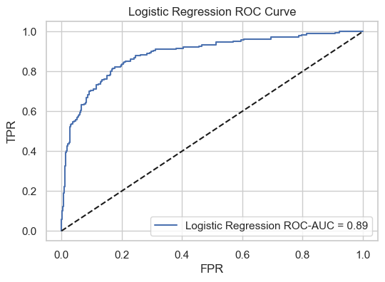

```
--- Random Forest ---
              precision    recall  f1-score   support

         0.0       0.98      0.99      0.99       936
         1.0       0.97      0.88      0.92       190

    accuracy                           0.98      1126
   macro avg       0.97      0.94      0.95      1126
weighted avg       0.98      0.98      0.97      1126

ROC-AUC: 0.9974021592442645
```

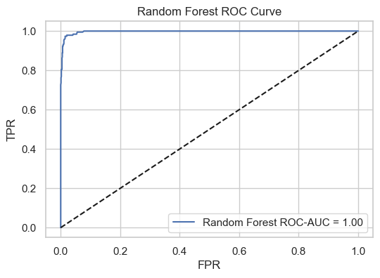

```
--- XGBoost ---
              precision    recall  f1-score   support

         0.0       1.00      0.99      0.99       936
         1.0       0.96      0.98      0.97       190

    accuracy                           0.99      1126
   macro avg       0.98      0.99      0.98      1126
weighted avg       0.99      0.99      0.99      1126

ROC-AUC: 0.9980206927575348
```

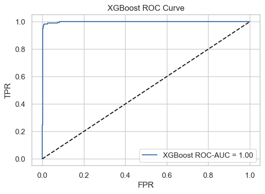

```python
def evaluate_model(y_test, y_pred, y_prob, model_name):
    print(f"--- {model_name} ---")
    print(classification_report(y_test, y_pred))
    print("ROC-AUC:", roc_auc_score(y_test, y_prob))
    fpr, tpr, _ = roc_curve(y_test, y_prob)
    plt.figure(figsize=(6,4))
    plt.plot(fpr, tpr, label=f"{model_name} ROC-AUC = {roc_auc_score(y_test, y_prob):.2f}")
    plt.plot([0,1],[0,1],'k--')
    plt.xlabel("FPR")
    plt.ylabel("TPR")
    plt.title(f"{model_name} ROC Curve")
    plt.legend()
    plt.show()

evaluate_model(y_test, y_pred_lr, y_prob_lr, "Logistic Regression")
evaluate_model(y_test, y_pred_rf, y_prob_rf, "Random Forest")
evaluate_model(y_test, y_pred_xgb, y_prob_xgb, "XGBoost")
```

**Insight:** Random Forest and XGBoost capture non-linear relationships and provide feature importance for actionable insights. XGBoost and Random Forest perform the best.so we will tune both model.

# 10. Hyperparameter Tuning

Hyperparameters are “settings” for a machine learning model.

We use **GridSearchCV** to find the BEST settings for:

- Random Forest
- XGBoost

```python
rf_params = {'n_estimators':[200,300], 'max_depth':[5,10,None], 'min_samples_split':[2,5]}
xgb_params = {'n_estimators':[200,300], 'max_depth':[3,5], 'learning_rate':[0.05,0.1]}

rf_grid = GridSearchCV(rf, rf_params, scoring='f1', cv=StratifiedKFold(5), n_jobs=-1)
rf_grid.fit(X_train_scaled, y_train)
best_rf = rf_grid.best_estimator_
print("Best RF Params:", rf_grid.best_params_)

xgb_grid = GridSearchCV(xgb, xgb_params, scoring='f1', cv=StratifiedKFold(5), n_jobs=-1)
xgb_grid.fit(X_train_scaled, y_train)
best_xgb = xgb_grid.best_estimator_
print("Best XGB Params:", xgb_grid.best_params_)
```

```
Best RF Params: {'max_depth': None, 'min_samples_split': 2, 'n_estimators': 300}
Best XGB Params: {'learning_rate': 0.1, 'max_depth': 5, 'n_estimators': 300}
```

The Random Forest will learn very detailed patterns using many trees and deep splits. It’s strong but can overfit slightly.

XGBoost is boosting, meaning it learns mistakes step by step. Depth 5 and learning rate 0.1 is a good balance between accuracy and avoiding overfitting.

# 11. Threshold Optimization

By default, predictions use a threshold of **0.5**.  
But churn prediction often needs **higher recall**.

So we:

1. Try many thresholds
2. Calculate F1-score for each
3. Pick the best threshold

```python
from sklearn.metrics import precision_recall_curve

probs = best_xgb.predict_proba(X_test_scaled)[:, 1]
precision, recall, thresholds = precision_recall_curve(y_test, probs)
f1 = 2 * (precision * recall) / (precision + recall + 1e-10)
best_idx = f1.argmax()
opt_thresh = thresholds[best_idx]

print(f"Optimal threshold: {opt_thresh:.2f}, F1: {f1[best_idx]:.2f}")

y_pred_opt = (probs >= opt_thresh).astype(int)
print(classification_report(y_test, y_pred_opt))
```

```
Optimal threshold: 0.66, F1: 0.96
              precision    recall  f1-score   support

         0.0       0.99      0.99      0.99       936
         1.0       0.96      0.97      0.96       190

    accuracy                           0.99      1126
   macro avg       0.98      0.98      0.98      1126
weighted avg       0.99      0.99      0.99      1126
```

# 12. Feature Importance

**Business Interpretation:**

- Low LoyaltyScore → trigger retention campaigns
- High DaySinceLastOrder → target re-engagement offers
- Feature contributions help personalize marketing interventions

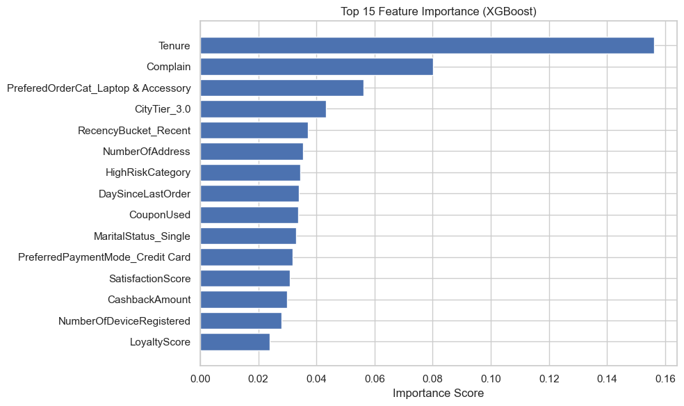

```
Top 15 Feature Importance:
Tenure: 0.1563
Complain: 0.0802
PreferedOrderCat_Laptop & Accessory: 0.0562
CityTier_3.0: 0.0433
RecencyBucket_Recent: 0.0370
NumberOfAddress: 0.0353
HighRiskCategory: 0.0345
DaySinceLastOrder: 0.0339
CouponUsed: 0.0336
MaritalStatus_Single: 0.0331
PreferredPaymentMode_Credit Card: 0.0319
SatisfactionScore: 0.0308
CashbackAmount: 0.0299
NumberOfDeviceRegistered: 0.0279
LoyaltyScore: 0.0239
```

```python
# Feature Importance using XGBoost
import matplotlib.pyplot as plt

# Get feature importance from XGBoost
feature_importance = best_xgb.feature_importances_
features = X.columns
indices = np.argsort(feature_importance)[-15:]  # Top 15 features

plt.figure(figsize=(10, 6))
plt.barh(range(len(indices)), feature_importance[indices])
plt.yticks(range(len(indices)), [features[i] for i in indices])
plt.xlabel('Importance Score')
plt.title('Top 15 Feature Importance (XGBoost)')
plt.tight_layout()
plt.show()

# Print top features
print("Top 15 Feature Importance:")
for idx in reversed(indices):
    print(f"{features[idx]}: {feature_importance[idx]:.4f}")
```

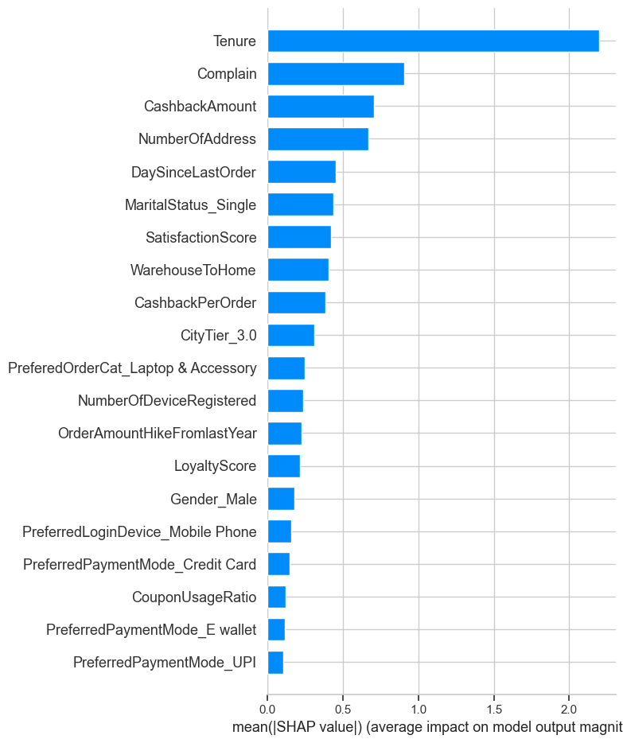

```python
# SHAP Explainability

try:
    explainer = shap.TreeExplainer(best_xgb)
    shap_values = explainer.shap_values(X_test_scaled)

    shap.summary_plot(shap_values, X_test, plot_type="bar", show=False)
    plt.show()

except Exception as e:
    print("SHAP not available:", e)
```

# 13. Fairness & Subgroup Analysis

```python
subgroups = ['Gender','CityTier']

# Get the part of clean_df that corresponds to the test set indices
original_X_test_data = clean_df.loc[X_test.index]

for col in subgroups:
    print(f"\nF1-score by {col}:")
    for val in original_X_test_data[col].unique():
        # Create mask based on the original column values in the test set
        mask = (original_X_test_data[col] == val)
        # Apply mask to y_test and X_test_scaled
        f1 = f1_score(y_test[mask], best_xgb.predict(X_test_scaled[mask]))
        print(f"{val}: {f1:.2f}")
```

```
F1-score by Gender:
Male: 0.95
Female: 0.93

F1-score by CityTier:
3.0: 0.94
1.0: 0.94
2.0: 1.00
```

# 14. KPI Dashboard

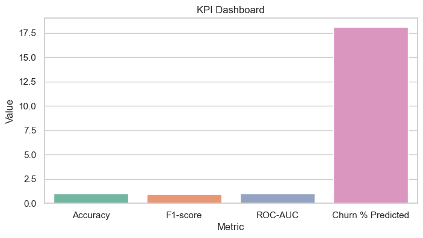

|  | Metric | Value |
| --- | --- | --- |
| 0 | Accuracy | 0.980462 |
| 1 | F1-score | 0.944162 |
| 2 | ROC-AUC | 0.998426 |
| 3 | Churn % Predicted | 18.117229 |

```python
kpi_df = pd.DataFrame({
    'Metric':['Accuracy','F1-score','ROC-AUC','Churn % Predicted'],
    'Value':[accuracy_score(y_test, best_xgb.predict(X_test_scaled)),
             f1_score(y_test, best_xgb.predict(X_test_scaled)),
             roc_auc_score(y_test, best_xgb.predict_proba(X_test_scaled)[:,1]),
             (best_xgb.predict(X_test_scaled).sum()/len(y_test))*100]
})

plt.figure(figsize=(8,4))
sns.barplot(x='Metric', y='Value', data=kpi_df, palette='Set2')
plt.title("KPI Dashboard")
plt.show()
display(kpi_df)
```

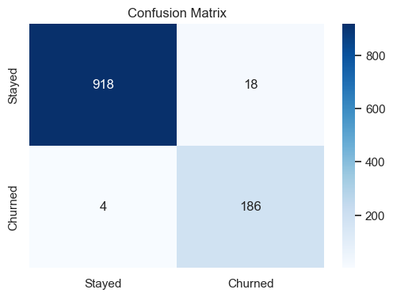

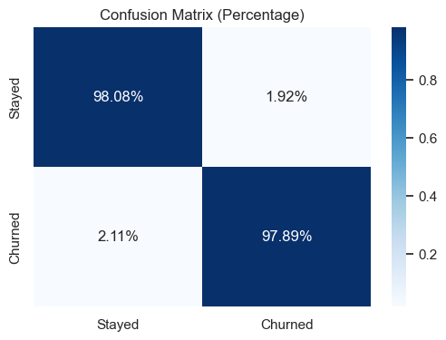

```
Confusion Matrix DataFrame:
         Predicted Stayed  Predicted Churned
Stayed                918                 18
Churned                 4                186
```

```python
# Confusion Matrix
cm = confusion_matrix(y_test, best_xgb.predict(X_test_scaled))
plt.figure(figsize=(6,4))
sns.heatmap(cm, annot=True, fmt='d', cmap='Blues', xticklabels=['Stayed','Churned'], yticklabels=['Stayed','Churned'])
plt.title('Confusion Matrix')
plt.show()

# confusion matrix analysis percentage
cm_percent = cm.astype('float') / cm.sum(axis=1)[:, np.newaxis]
plt.figure(figsize=(6,4))
sns.heatmap(cm_percent, annot=True, fmt='.2%', cmap='Blues', xticklabels=['Stayed','Churned'], yticklabels=['Stayed','Churned'])
plt.title('Confusion Matrix (Percentage)')
plt.show()

# confusion matrix in dataframe
cm_df = pd.DataFrame(cm, index=['Stayed','Churned'], columns=['Predicted Stayed','Predicted Churned'])
print("Confusion Matrix DataFrame:")
print(cm_df)
```

```python
#recall analysis
tn, fp, fn, tp = cm.ravel()
recall_stayed = tn / (tn + fp)
recall_churned = tp / (tp + fn)
print(f"Recall for Stayed: {recall_stayed:.2f}")
print(f"Recall for Churned: {recall_churned:.2f}")
```

```
Recall for Stayed: 0.98
Recall for Churned: 0.98
```

The model achieved a recall of 0.98 for churners, meaning it successfully identifies 98% of customers who are at risk of leaving. This shows that the model is highly effective at detecting churn and minimizing false negatives.

# 15. Ethical & Compliance Considerations

```python
ethical_plan = """
Ensure fairness across gender, city tier, age
Bias testing by subgroup metrics
Avoid discriminatory targeting
Maintain GDPR and data privacy compliance
"""
print(ethical_plan)
```

```
Ensure fairness across gender, city tier, age
Bias testing by subgroup metrics
Avoid discriminatory targeting
Maintain GDPR and data privacy compliance
```

# 16. Save Models for Deployment

```python
joblib.dump(best_xgb, "xgb_best_model.pkl")
joblib.dump(scaler, "scaler.pkl")
print("Model & scaler saved for deployment")
```

```
Model & scaler saved for deployment
```

```python
booster = best_xgb.get_booster()
booster.save_model("xgb_shap_model.json")
print("XGBoost model saved in JSON format for SHAP analysis")
```

```
XGBoost model saved in JSON format for SHAP analysis
```

```python
clean_booster = xgb.Booster()
clean_booster.load_model("xgb_shap_model.json")
print("XGBoost model loaded from JSON for SHAP analysis")
```

[output not shown]

## . Observations & Recommendations Summary

| Feature / Metric | Observation | Recommended Action | Phase for Action |
| --- | --- | --- | --- |
| LoyaltyScore | Low score indicates low engagement | Send loyalty/reward campaigns | Post-Onboarding / Early Usage |
| DaySinceLastOrder | High value → customer inactive | Re-engagement emails/discounts | Inactivity / Dormant Phase |
| CouponUsageRatio | Low usage → lack of incentives | Targeted coupons or promotions | Purchase / Engagement Phase |
| ComplaintFrequency | High → dissatisfied customer | Personalized support / follow-up | Anytime complaints are logged |
| CashbackPerOrder | Low → less satisfaction with incentives | Optimize cashback program | Purchase Phase |
| HighRiskCategory | Certain product categories more likely to churn | Extra loyalty offers / exclusive deals | Product-Specific Campaigns |
| App Usage Metrics | Low engagement → likely to churn | Push notifications, app tutorials | Post-Onboarding / Early Usage |

## Key Takeaways for Action Before Customer Leaves

**Continuous Monitoring:** The churn prediction should run after every interaction or purchase, not just periodically.

**Early Warning Indicators:** Use LoyaltyScore, RecencyBucket, and ComplaintFrequency to catch high-risk customers before they churn.

**Targeted Campaigns:** Automated alerts in CRM for marketing/retention teams to take immediate action.

**Feedback Loop:** Actions (coupons, support, incentives) are logged and used to update model predictions dynamically.

# Customer Lifecycle Phases & Churn Prediction Integration

| Phase | What Happens | Where to Integrate Churn Prediction | Actionable Insights / Interventions |
| --- | --- | --- | --- |
| **Onboarding** | Customer signs up, first interactions | Predict churn risk based on early behavior (app usage, first purchase, preferred categories) | Send welcome campaigns, tutorials, personalized recommendations |
| **Early Engagement / First 1-3 Orders** | Customer explores products and app | Monitor LoyaltyScore, CouponUsageRatio, and App Engagement metrics | Incentivize with coupons, loyalty points, targeted push notifications |
| **Purchase / Active Phase** | Customer regularly purchases | Use churn model to flag risk after each order | Trigger special offers, discount bundles, cashback improvements for high-risk users |
| **Dormant / Inactive Phase** | Customer hasn’t purchased recently | Predict churn based on DaySinceLastOrder, CashbackPerOrder, RecencyBucket | Re-engagement campaigns: emails, push notifications, exclusive deals |
| **Complaint / Dissatisfaction Phase** | Customer files complaints or shows low satisfaction | Monitor ComplaintFrequency and SatisfactionScore in real time | Personalized support calls, priority resolution, feedback loop |
| **High-Risk Product Categories** | Purchase pattern in risky categories (e.g., Mobile Phone) | Integrate high-risk category flag into churn prediction | Exclusive retention offers, loyalty bonuses, cross-sell recommendations |

# 17. Next Steps

1. Deploy best model (Tuned XGBoost/Random Forest) as REST API
2. Integrate predictions into CRM
3. Trigger personalized campaigns for high-risk customers
4. Monitor KPIs weekly/monthly
5. Retrain model regularly based on drift
6. Provide executive dashboards summarizing churn risk & revenue impact